# 260-2015-10-23-psychopathology-I

2015-10-23 12:46:02

## Prelude

[video not shown]

## Prelude II

[video not shown]

## Announcements

- **No class next Wednesday, 10/28**

## Today's Topics

- Wrap up on [fear/anxiety/stress](https://rawgit.com/psu-psychology/psych-260/master/lectures/2015-10-21/260-2015-10-21-fear-stress.html)
- From normal to abnormal emotional expression

## Major affective (emotional) disorders

- Types
  - Bipolar disorder
  - Depression
  - Anxiety
- Heritability
  - *proportion of variance in trait accounted for by genetic factors*
  - Monozygotic: .69
  - Dizygotic: .13

## Depression

- Symptoms
  - Insomnia, lethargy, loss of pleasure, interest, energy
- Agitation
- Lasting for several weeks or more
- Prevalence (~10% lifetime)
- Females 2-3x males

## Neurological factors

- Reduced hippocampal volumes
- [(Videbech and Ravnkilde 2004)](http://dx.doi.org/10.1176/appi.ajp.161.11.1957) meta-analysis
- Meta-analysis combines effects across many different studies

## [(Videbech and Ravnkilde 2004)](http://dx.doi.org/10.1176/appi.ajp.161.11.1957)

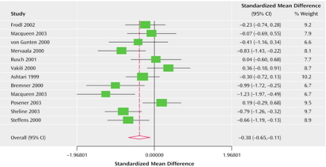

## [(Videbech and Ravnkilde 2004)](http://dx.doi.org/10.1176/appi.ajp.161.11.1957)

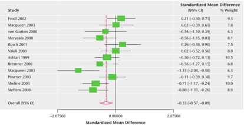

## Neurological factors

- Hypoactivity in
  - Frontal and temporal cortex
  - Anterior cingulate
  - Insula
  - Cerebellum
- [(Fitzgerald et al. 2008)](http://dx.doi.org/10.1002/hbm.20426)

## [(Fitzgerald et al. 2008)](http://dx.doi.org/10.1002/hbm.20426)

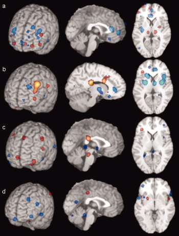

1. patients v. controls, (b) patients on SSRIs, (c) patients v. ctrls (happy stim), (d) patients v. controls (sad stim)

## Neurological Factors

- Persistent activation in amygdala
- Amygdala and dorsolateral prefrontal cortex (DLPFC) inversely related
- (Siegle et al. 2002)

## (Siegle et al. 2002)

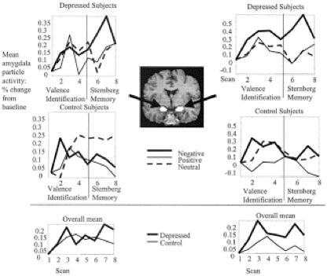

## (Siegle et al. 2002)

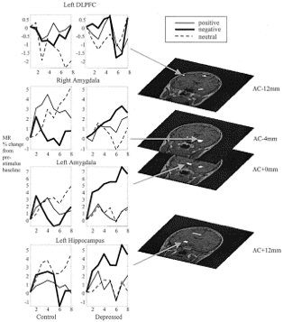

## Disturbed sleep

- Less slow wave (stage 3 and 4)
- More REM earlier in night (typical is longer REM as night goes on)

[figure not shown]

## Pharmacological factors

- Lowered thyroid function
- High/chronic cortisol levels
- Monoamine hypothesis
  - More: euphoria
  - Less: depression
  - Resperine (antagonist for NE & 5-HT) can cause depression
  - Low serotonin (5-HT) metabolite levels in CSF of suicidal depressives [(Samuelsson et al. 2006)](http://dx.doi.org/10.1111/j.1600-0447.2005.00639.x)

## [(Samuelsson et al. 2006)](http://dx.doi.org/10.1111/j.1600-0447.2005.00639.x)

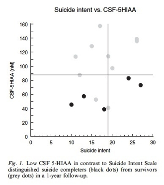

## Treatments for depression

- Psychotherapy
  - Often effective when combined with drug treatment
- Drugs
- Exercise
- Electroconvulsive Shock (ECT)

## Drugs

- Monoamine oxidase (MAO) inhibitors
  - MAO destroys excess monoamines in terminal buttons
  - MAO-I’s boost monoamine levels
- Tricyclics
  - Inhibit NE, 5-HT reuptake
  - Upregulate monoamine levels, but non-selective = side effects

## Drugs

- Selective Serotonin Reuptake Inhibitors (SSRIs)
  - Fluoxetine (Prozac, Paxil, Zoloft)
  - Prolong duration 5-HT in synaptic cleft
  - Also increase brain steroid production
- Selective Norepinephrine Reuptake Inhibitors (SNRIs)

## Problems with monoamine hypothesis

- Too simplistic
- NE, 5-HT interact
- Drugs fast acting (min), but improvement slow (weeks)

## What do drugs do, then?

- Receptor sensitivity altered?
  - Serotonin autoreceptors compensate
  - Postsynaptic upregulation of NE/5-HT effects
  - Link to neurotrophin BDNF
  - BDNF boosts neurogenesis

## Cybalta Ad

[video not shown]

## Prozac ad

[video not shown]

## What do you think?

- How closely should drug advertising be regulated?
- Should some patients get treatment X because they ask for it?

## Exercise as a treatment

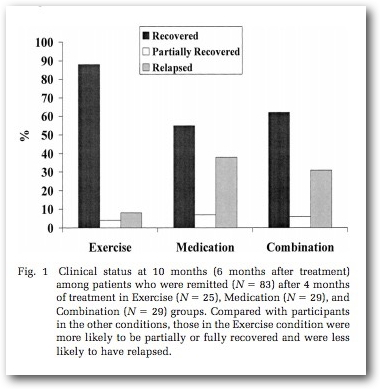

[(Babyak et al. 2000)](http://journals.lww.com/psychosomaticmedicine/Abstract/2000/09000/Exercise_Treatment_for_Major_Depression_.6.aspx)

## Drugs vs. therapy

[figure not shown]

[(DeRubeis, Siegle, and Hollon 2008)](http://dx.doi.org/10.1038/nrn2345)

## [(DeRubeis, Siegle, and Hollon 2008)](http://dx.doi.org/10.1038/nrn2345)

[figure not shown]

## [(DeRubeis, Siegle, and Hollon 2008)](http://dx.doi.org/10.1038/nrn2345)

[figure not shown]

## [(DeRubeis, Siegle, and Hollon 2008)](http://dx.doi.org/10.1038/nrn2345)

[figure not shown]

## Depression's widespread impact

- Widespread brain dysfunction
- Prefrontal cortex, amygdala, HPA axis, circadian rhythms
- Genetic + environmental factors
- Disturbance in 5-HT, NE systems, cortisol

## References

Babyak, Michael, James A Blumenthal, Steve Herman, Parinda Khatri, Murali Doraiswamy, Kathleen Moore, W Edward Craighead, Teri T Baldewicz, and K Ranga Krishnan. 2000. “Exercise Treatment for Major Depression: Maintenance of Therapeutic Benefit at 10 Months.” *Psychosomatic Medicine* 62 (5). LWW: 633–38. http://journals.lww.com/psychosomaticmedicine/Abstract/2000/09000/Exercise_Treatment_for_Major_Depression_.6.aspx.

DeRubeis, Robert J., Greg J. Siegle, and Steven D. Hollon. 2008. “Cognitive Therapy Versus Medication for Depression: Treatment Outcomes and Neural Mechanisms.” *Nature Reviews Neuroscience* 9 (10): 788–96. doi:10.1038/nrn2345.

Fitzgerald, Paul B., Angela R. Laird, Jerome Maller, and Zafiris J. Daskalakis. 2008. “A Meta-Analytic Study of Changes in Brain Activation in Depression.” *Human Brain Mapping* 29 (6): 683–95. doi:10.1002/hbm.20426.

Samuelsson, M., J. Jokinen, A.-L. Nordström, and P. Nordström. 2006. “CSF 5-HIAA, Suicide Intent and Hopelessness in the Prediction of Early Suicide in Male High-Risk Suicide Attempters.” *Acta Psychiatrica Scandinavica* 113 (1): 44–47. doi:10.1111/j.1600-0447.2005.00639.x.

Siegle, Greg J., Stuart R. Steinhauer, Michael E. Thase, V. Andrew Stenger, and Cameron S. Carter. 2002. “Can’t Shake That Feeling: Event-Related fMRI Assessment of Sustained Amygdala Activity in Response to Emotional Information in Depressed Individuals.” *Biological Psychiatry* 51 (9): 693–707. doi:10.1016/S0006-3223(02)01314-8.

Videbech, Poul, and Barbara Ravnkilde. 2004. “Hippocampal Volume and Depression: A Meta-Analysis of MRI Studies.” *American Journal of Psychiatry* 161 (11). Am Psychiatric Assoc: 1957–66. doi:10.1176/appi.ajp.161.11.1957.